# Startup Investment Analysis

# Visualizations

## 1. Deals vs No Deals

**Insight:** Majority of pitches do secure a deal, showing the competitive nature of Shark Tank.

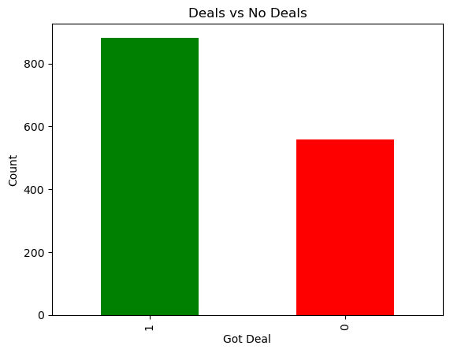

```python
dataset['Got Deal'].value_counts().plot(kind='bar', color=['green','red'])
plt.title("Deals vs No Deals")
plt.xlabel("Got Deal")
plt.ylabel("Count")
plt.show()
```

## 2. Total Investment per Season

**Insight:** Some seasons saw significantly higher total investments, reflecting growth in show popularity and bigger deals.

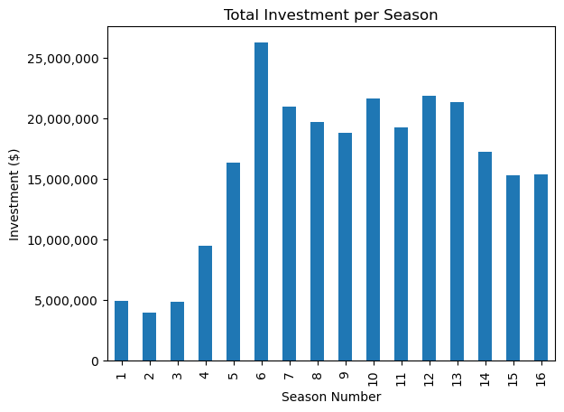

```python
dataset.groupby('Season Number')['Total Deal Amount'].sum().plot(kind='bar')
plt.title("Total Investment per Season")
plt.ylabel("Investment ($)")
plt.gca().yaxis.set_major_formatter(ticker.FuncFormatter(lambda x, pos: f'{int(x):,}'))
plt.show()
```

## 3. Average Valuation Requested per Season

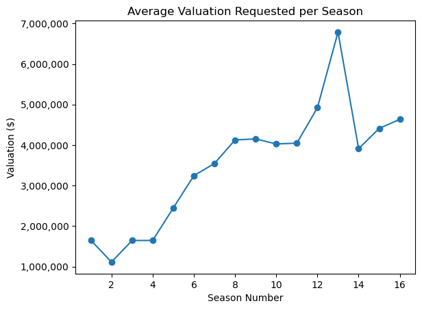

```python
dataset.groupby('Season Number')['Valuation Requested'].mean().plot(kind='line', marker='o')
plt.title("Average Valuation Requested per Season")
plt.ylabel("Valuation ($)")
plt.gca().yaxis.set_major_formatter(ticker.FuncFormatter(lambda x, pos: f'{int(x):,}'))
plt.show()
```

## 4. Top Industries by Pitch Count

**Insight:** Food, Lifestyle, Fashion dominate the pitch landscape.

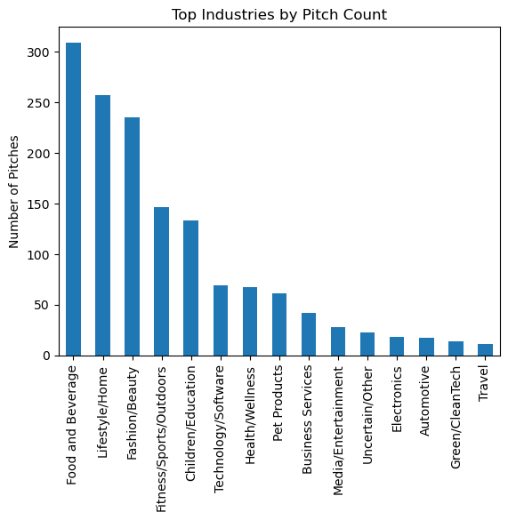

```python
dataset['Industry'].value_counts().head(15).plot(kind='bar')
plt.title("Top Industries by Pitch Count")
plt.ylabel("Number of Pitches")
plt.show()
```

## 5. Total Deal Amount by Industry

**Insight:** Some industries attract much higher funding even if pitch counts are lower.

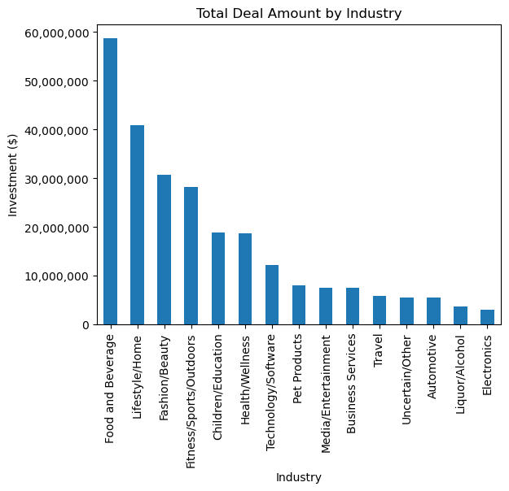

```python
dataset.groupby('Industry')['Total Deal Amount'].sum().sort_values(ascending=False).head(15).plot(kind='bar')
plt.title("Total Deal Amount by Industry")
plt.ylabel("Investment ($)")
plt.gca().yaxis.set_major_formatter(ticker.FuncFormatter(lambda x, pos: f'{int(x):,}'))
plt.show()
```

## 6. Average Equity Asked vs Equity Given

**Insight:** Entrepreneurs usually give up more equity than they initially offered.

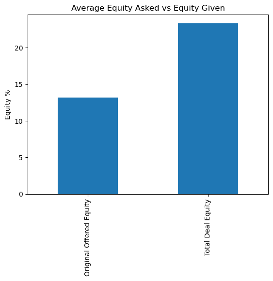

```python
dataset[['Original Offered Equity','Total Deal Equity']].mean().plot(kind='bar')
plt.title("Average Equity Asked vs Equity Given")
plt.ylabel("Equity %")
plt.show()
```

## 7. Distribution of Entrepreneurs’ Average Age

**Insight:** Most entrepreneurs fall in the Middle (20–40) age group.

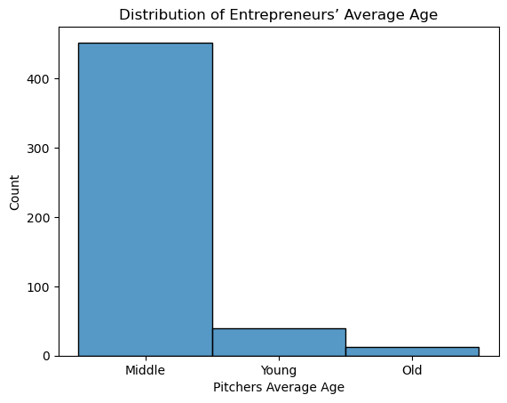

```python
sns.histplot(dataset['Pitchers Average Age'].dropna(), bins=15)
plt.title("Distribution of Entrepreneurs’ Average Age")
plt.show()
```

## 8. Top 10 Pitchers Cities

**Insight:** Certain cities dominate entrepreneurship (NY, LA, etc.).

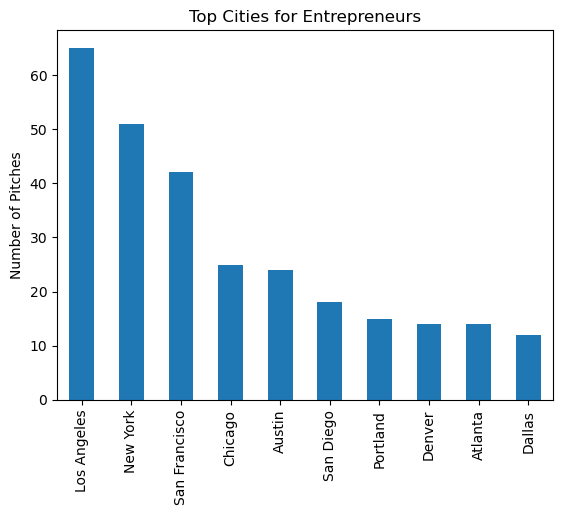

```python
dataset['Pitchers City'].value_counts().head(10).plot(kind='bar')
plt.title("Top Cities for Entrepreneurs")
plt.ylabel("Number of Pitches")
plt.show()
```

## 9. Funding Success Rate by Industry

**Insight:** Industries like Automotive tend to succeed more than Lifestyle.

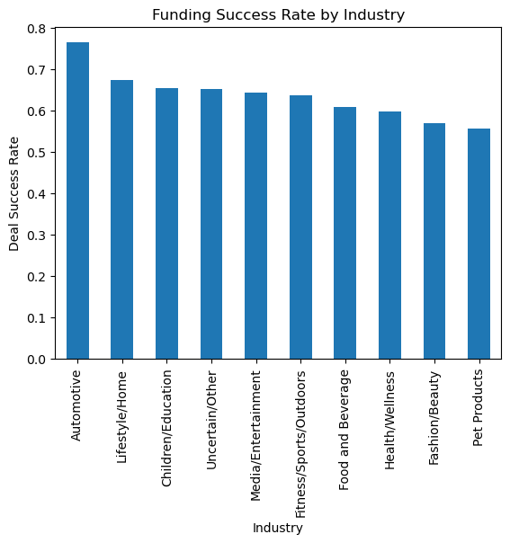

```python
success_rate = dataset.groupby('Industry')['Got Deal'].mean().sort_values(ascending=False).head(10)
success_rate.plot(kind='bar')
plt.title("Funding Success Rate by Industry")
plt.ylabel("Deal Success Rate")
plt.show()
```

## 10. Sharks Total Investment Amount

**Insight:** Mark Cuban generally invests the most.

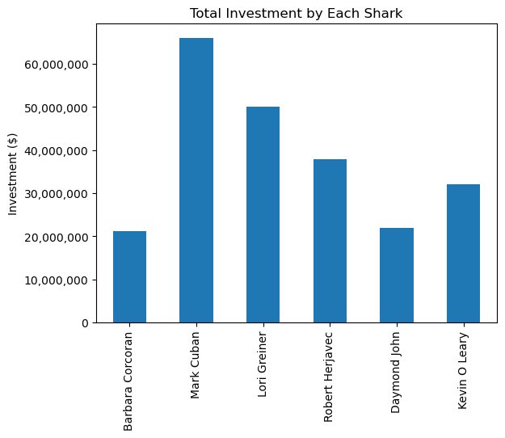

```python
sharks = {
    'Barbara Corcoran': dataset['Barbara Corcoran Investment Amount'].sum(),
    'Mark Cuban': dataset['Mark Cuban Investment Amount'].sum(),
    'Lori Greiner': dataset['Lori Greiner Investment Amount'].sum(),
    'Robert Herjavec': dataset['Robert Herjavec Investment Amount'].sum(),
    'Daymond John': dataset['Daymond John Investment Amount'].sum(),
    'Kevin O Leary': dataset['Kevin O Leary Investment Amount'].sum()
}
pd.Series(sharks).plot(kind='bar')
plt.title("Total Investment by Each Shark")
plt.ylabel("Investment ($)")
plt.gca().yaxis.set_major_formatter(ticker.FuncFormatter(lambda x, pos: f'{int(x):,}'))
plt.show()
```

## 11. Sharks Average Equity Taken

**Insight:** Sharks vary in negotiation style. Daymond John often pushes for higher equity.

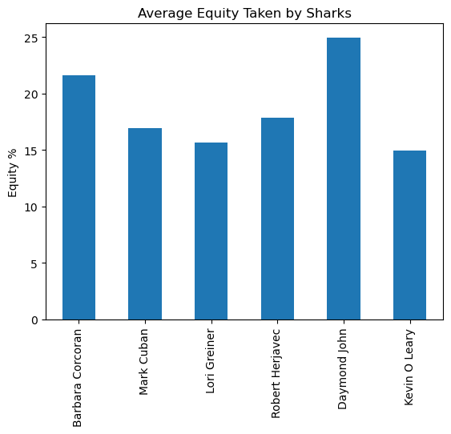

```python
equity = {
    'Barbara Corcoran': dataset['Barbara Corcoran Investment Equity'].mean(),
    'Mark Cuban': dataset['Mark Cuban Investment Equity'].mean(),
    'Lori Greiner': dataset['Lori Greiner Investment Equity'].mean(),
    'Robert Herjavec': dataset['Robert Herjavec Investment Equity'].mean(),
    'Daymond John': dataset['Daymond John Investment Equity'].mean(),
    'Kevin O Leary': dataset['Kevin O Leary Investment Equity'].mean()
}
pd.Series(equity).plot(kind='bar')
plt.title("Average Equity Taken by Sharks")
plt.ylabel("Equity %")
plt.show()
```

## 12. Distribution of Number of Sharks in Deals

**Insight:** Most deals involve 1–2 sharks.

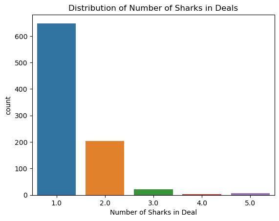

```python
sns.countplot(x='Number of Sharks in Deal', data=dataset)
plt.title("Distribution of Number of Sharks in Deals")
plt.show()
```

## 13. Guest Shark Participation

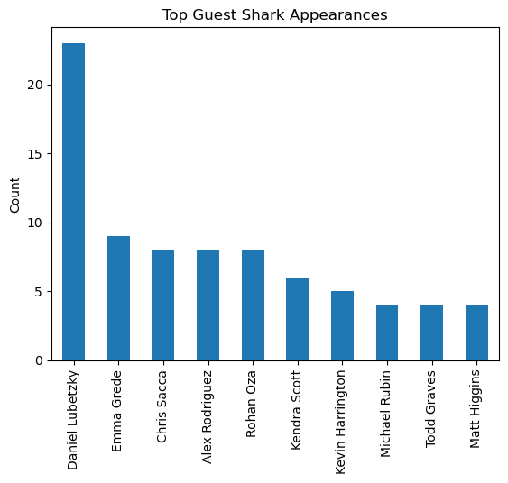

```python
dataset['Guest Name'].value_counts().head(10).plot(kind='bar')
plt.title("Top Guest Shark Appearances")
plt.ylabel("Count")
plt.show()
```

# Conclusion